# STAT340: Discussion 8: Linear regression

## Exercise: modeling earthquake frequency and intensity

Today, we will be using real data from the [US Geological Survey (USGS)](https://www.usgs.gov/natural-hazards/earthquake-hazards/earthquakes) to build a model to estimate how the intensity of earthquakes relates to their frequency around the world.

### Background

In seismology, the study of earthquakes, the relationship between the frequency and magnitude of earthquakes can be modeled by the [Gutenberg-Richter (GR) law](https://en.wikipedia.org/wiki/Gutenberg%E2%80%93Richter_law). Let $M$ be the [Richter magnitude](https://en.wikipedia.org/wiki/Richter_magnitude_scale) of a seismic event (roughly speaking, the amount of energy released by an earthquake), and $N$ be the number of events with magnitude **at least $M$** (i.e., greater than or equal to $M$). The GR law states that

$$N \approx 10^{a-bM},$$

where $a$ and $b$ are constants that depend on the particular choice of place/period. In other words, taking the logarithm of both sides,

$$\log_{10}(N) \approx a-bM$$

Note that this relationship should appear as a straight line if we plot $\log_{10}(N)$ as a function of $M$.

This linear relationship between the log of the number of earthquakes of a given magnitude and the magnitude suggests that we can use linear regression to estimate the values of $a$ and $b$. Let’s do that!

### Importing the data

Our dataset contains every earthquake (on Earth) of magnitude 4.5 or greater that was detected by USGS from beginning of 2011 to end of 2023. A detailed description of the columns can be found [here](https://earthquake.usgs.gov/data/comcat/data-eventterms.php), but the main variables we are interested in for the purposes of this exercise are are `time` (self explanatory) and `mag.binned` (magnitude rounded to nearest half integer).

For convenience, much of the data cleaning and preprocessing has already been done for you. You can download the prepared data on canvas. Be sure to save this file in the same directory as where you are running this source file. If you’re not sure, run `getwd()` to ask R for the current working directory and save the file there.

```r
quakes = read.csv( 'quakes.csv' )
```

Since this is a bit tricky, it’s been done for you below using tidyverse tools. We recommend that you read through this block of code carefully to make sure you have at least a high-level understanding of what it is doing. It is good to get practice with these sorts of data processing tricks, even if they aren’t the main point of the course.

```r
library(tidyverse)
quakes.count = quakes %>%
   count(year,mag.binned,name='count') %>%
   group_by(year) %>%
   mutate(N=rev(cumsum(rev(count))), year=as.character(year))

# NOTES:
# count(year,mag.binned) counts how many events with that magnitude occurred each year
#   (see https://dplyr.tidyverse.org/reference/count.html for more info)
#
# group_by(year) followed by cumsum(...) takes the cumulative sum in each year
# the rev(...rev(...)) runs this cumsum in reverse (otherwise we get ≤M instead of ≥M)
```

Before moving onto the next step, inspect the data frame to make sure you completely understand what it represents and check that everything looks right. Your first and last rows should look something like `2011, 4.5, 7430, 10636` and `2023, 8, 1, 1`.

```r
print(quakes.count,n=Inf)
```

```
## # A tibble: 105 × 4
## # Groups:   year [13]
##     year  mag.binned count     N
##     <chr>      <dbl> <int> <int>
##   1 2011         4.5  7430 10635
##   2 2011         5    2485  3205
##   3 2011         5.5   395   720
##   4 2011         6     235   325
##   5 2011         6.5    62    90
##   6 2011         7      21    28
##   7 2011         7.5     6     7
##   8 2011         8       1     1
##   9 2012         4.5  6137  9196
##  10 2012         5    2461  3059
##  11 2012         5.5   402   598
```

[output cut: 94 more lines]

**Question:** to check your understanding: what does each row in the data frame `quakes.count` represent? Given that we are going to treat each of these rows as an observation in our data, which column is the predictor in our regression described above? Which column is the response variable?

- Each row in the data frame includes four pieces of information: the year (year), the magnitude bin (mag.binned), the count of earthquakes within that magnitude bin for the year (count), and the cumulative count of earthquakes with a magnitude at least as strong as the magnitude bin for the year (N). This cumulative count (N) represents the number of earthquakes with a magnitude greater than or equal to mag.binned in a given year.
- The predictor variable in our regression is the magnitude bin (mag.binned).
- The response variable is the logarithm of the cumulative count of earthquakes (N), as the GR law indicates a linear relationship between $\log_{10}(N)$ and the magnitude $M$.

### Visualization

As usual, our first step is to visualize the data. Make a *scatter plot* of $\log_{10}(N)$ as a function of $M$. Note that this means $M$ is on the horizontal axis (we say “$y$ as a function of $x$, not”$x$ as a function of $y$“). Then, add a line plot on top showing the trajectory of each year, making sure the years are correctly grouped together and distinguished from each other. You might use something like `color` or `linetype`, or even something else use your best judgment.

**Note:** you can either use `log10(N)` as the `y` aesthetic, OR directly use `y=N` and just rescale the axis to be logarithmic using `scale_y_log10()`. I recommend this second method since it makes the axis easier to read (see [here](https://stackoverflow.com/a/9223257) for an example).

It should look something similar to (but not exactly the same as) the image below which is for an older version of this dataset (don’t forget to add a nice title and axis labels to your plot!):

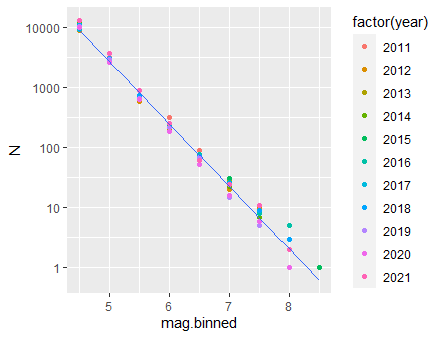

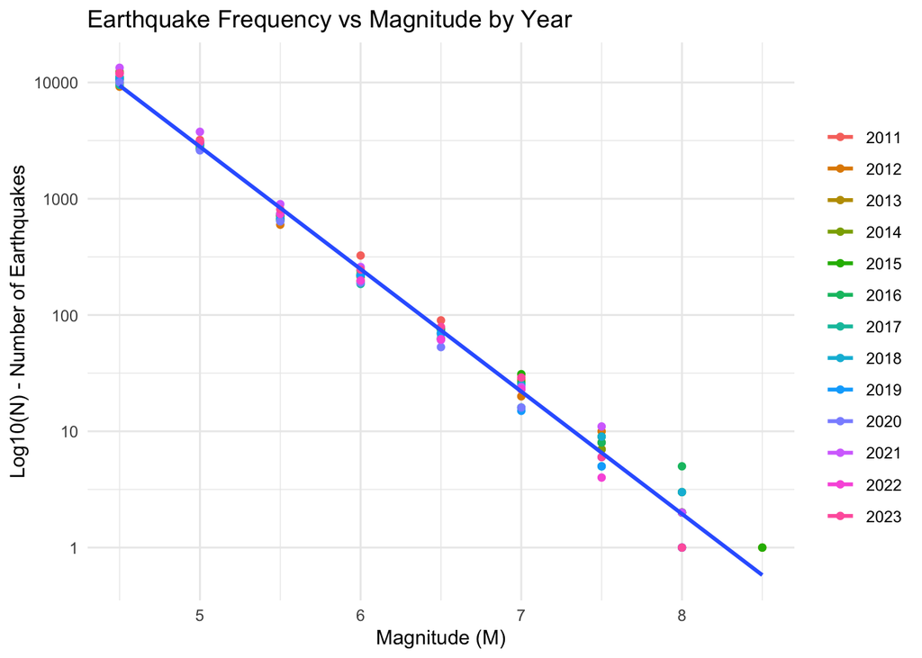

```r
# TODO: fill in the code below.
library(ggplot2)

ggplot(quakes.count, aes(x = mag.binned, y = N, group = year, color = as.factor(year))) +
  geom_point() +
  geom_smooth(method = "lm", aes(group = 1), se = FALSE) +
  scale_y_log10() +
  labs(title = "Earthquake Frequency vs Magnitude by Year",
       x = "Magnitude (M)",
       y = "Log10(N) - Number of Earthquakes") +
  theme_minimal() +
  theme(legend.title = element_blank())
```

### Estimation

```r
#TODO: fill in the code below.
# Fit linear regression model
model <- lm(log10(N) ~ mag.binned, data = quakes.count)

# Show summary of model
summary(model)
```

```
##
## Call:
## lm(formula = log10(N) ~ mag.binned, data = quakes.count)
##
## Residuals:
##      Min       1Q   Median       3Q      Max
## -0.28975 -0.06736  0.01041  0.05850  0.40922
##
## Coefficients:
##              Estimate Std. Error t value Pr(>|t|)
## (Intercept)  8.709950   0.061469   141.7   <2e-16 ***
## mag.binned  -1.052525   0.009628  -109.3   <2e-16 ***
## ---
## Signif. codes:  0 '***' 0.001 '**' 0.01 '*' 0.05 '.' 0.1 ' ' 1
##
## Residual standard error: 0.1153 on 103 degrees of freedom
## Multiple R-squared:  0.9915, Adjusted R-squared:  0.9914
## F-statistic: 1.195e+04 on 1 and 103 DF,  p-value: < 2.2e-16
```

From your fit, what are your estimates for the constants $a$ and $b$? Pay **careful attention** to the signs here! (hint: remember the GR law uses the convention $a-bM$ whereas R assumes you are fitting `intercept + slope * M`, so your fitted slope is $-b$).

Try to avoid copy-pasting or manually typing in values. The `coef()` function lets you extract coefficients from a model object (e.g. `lm.quakes`), or you can access the `coefficients` attribute of your fitted model directly. The result will be a vector, and you can then use `[i]` to access the i-th value of this coefficients vector. You may also want to use `unname()` at the end to remove the name from the value. If you don’t, it may carry through to later calculations and interfere with some downstream code.

```r
#TODO: fill in code below

coefficients <- coef(model)
a <- coefficients[1]
b <- -coefficients[2]

print(a)
```

```
## (Intercept)
##     8.70995
```

```r
print(b)
```

```
## mag.binned
##   1.052525
```

```r
print(a+b)
```

```
## (Intercept)
##    9.762475
```

**Hint:** if you did this correctly, `a+b` should evaluate to approximately `9.8`.

### Checking fit

It’s always nice to *visually check your fit* to make sure everything looks right. Plot the line of best fit along with the data points in the chunk below.

**Hint:** this time, we recommend using `log10(N)` as the `y` aesthetic, then using [`geom_abline()`](https://ggplot2.tidyverse.org/reference/geom_abline.html) to plot your regression lines using your estimated slope and intercept values. This avoids dealing with distorted axis caused by the other method’s `scale_y_log10()` which can be non-intuitive to deal with. Note that you can use your variables `a` and `b` here that were defined previously to avoid manually typing in numerical estimates (which is almost always bad!).

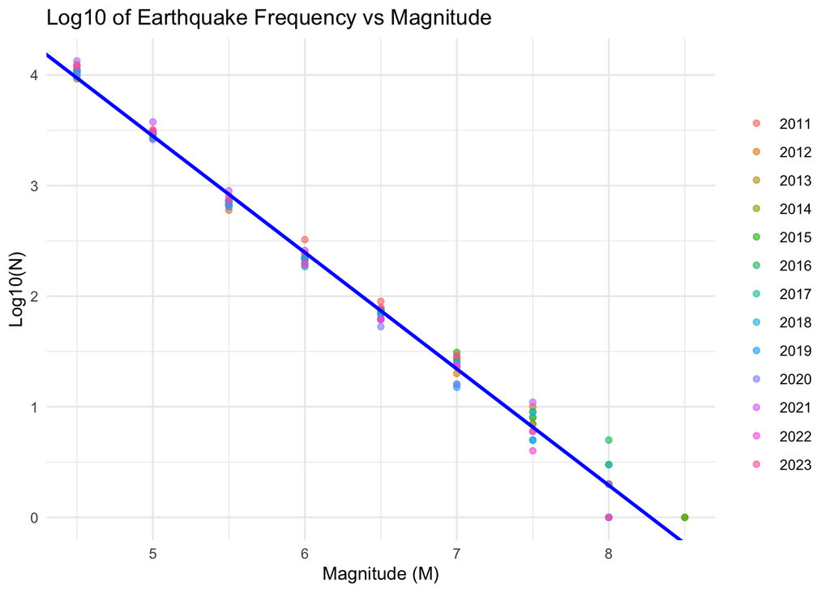

```r
#TODO: fill in code below

ggplot(quakes.count, aes(x = mag.binned, y = log10(N))) +
  geom_point(aes(color = as.factor(year)), alpha = 0.6) +
  geom_abline(intercept = a, slope = -b, color = "blue", size = 1) +
  labs(title = "Log10 of Earthquake Frequency vs Magnitude",
       x = "Magnitude (M)",
       y = "Log10(N)",
       color = "Year") +
  theme_minimal() +
  theme(legend.title = element_blank())
```

You can also check [the residuals of your fit](https://rpubs.com/iabrady/residual-analysis). This is fairly convenient to do in base R. Note that you will see some **heteroscedasticity** due to the fact that higher magnitude earthquakes occur much less frequently than lower magnitude earthquakes (thank goodness!), so we expect there to be more variation in our estimates for those magnitudes. This is to be expected, and not a huge problem. Aside from these extremes, you should be able to see that normality is mostly satisfied.

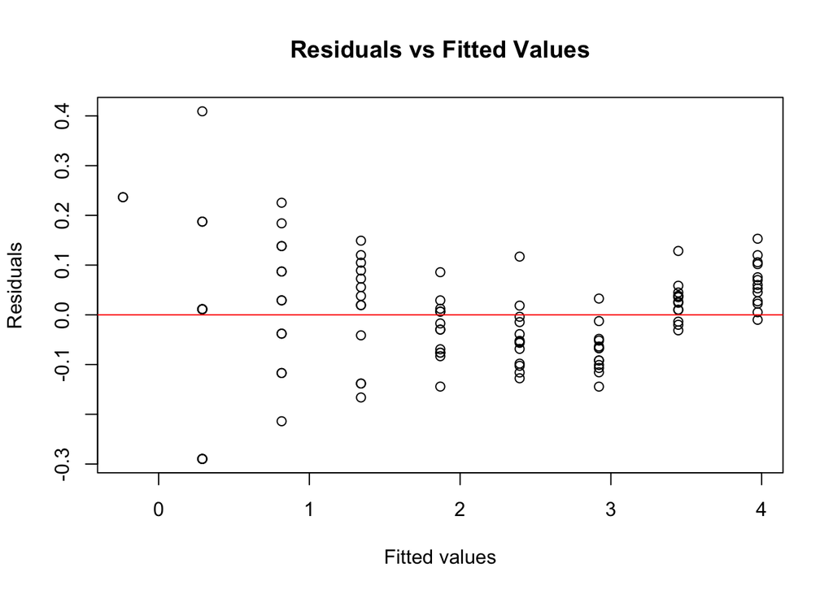

```r
#TODO: fill in code below
residuals <- resid(model)

# Plotting residuals vs fitted values to check for homoscedasticity
plot(fitted(model), residuals,
     xlab = "Fitted values", ylab = "Residuals",
     main = "Residuals vs Fitted Values")
abline(h = 0, col = "red")
```

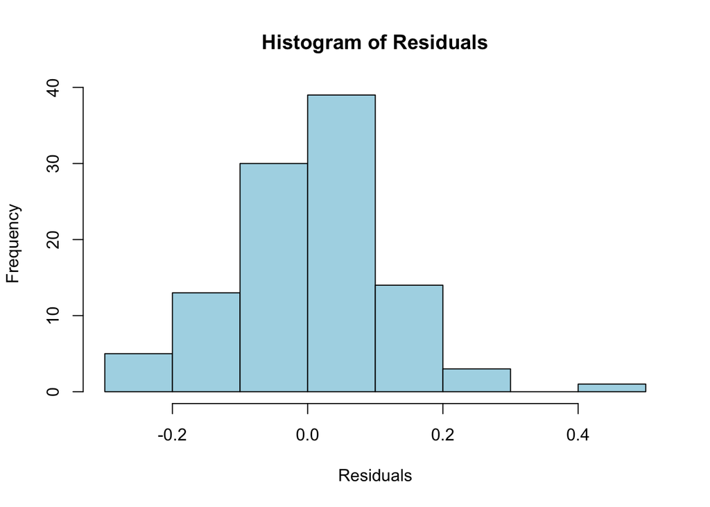

```r
# Plotting a histogram of residuals to check for normality
hist(residuals,
     main = "Histogram of Residuals",
     xlab = "Residuals",
     col = "lightblue", border = "black")
```

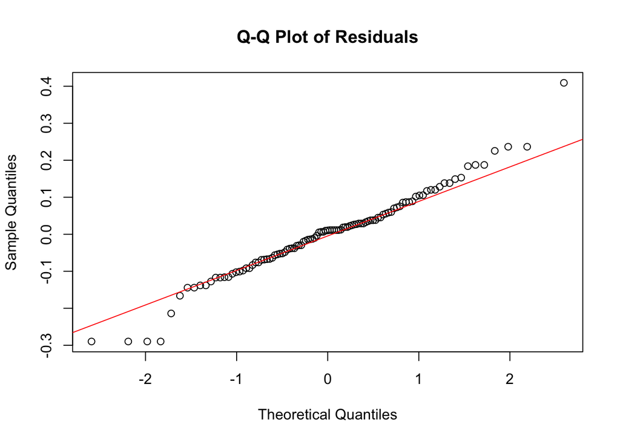

```r
# Q-Q plot to further check for normality
qqnorm(residuals, main = "Q-Q Plot of Residuals")
qqline(residuals, col = "red")
```

### Confidence intervals

Give $95\%$ confidence intervals for $a$ and $b$ (here is a [help page](https://www.rdocumentation.org/packages/stats/versions/3.6.2/topics/confint), if you need it).

```r
#TODO: fill in code below
conf_intervals <- confint(model, level = 0.95)
conf_intervals
```

```
##                 2.5 %    97.5 %
## (Intercept)  8.588041  8.831859
## mag.binned  -1.071621 -1.033429
```

Give a brief interpretation of these intervals.

### Making predictions

Let $N_{\ge 5}$ denote the number of earthquakes of magnitude 5 or greater should we expect to see on average each year. According to your estimated model, what is the approximate value of $N_{\ge 5}$? Give a brief explanation of your reasoning below.

```r
# TODO: perform calculations here
M <- 5
N_ge_5 <- 10^(a - b * M)
N_ge_5
```

```
## (Intercept)
##    2801.074
```

- This means that, according to your model, we would expect to see, on average, about 2801 earthquakes of magnitude 5 or greater each year globally, based on the dataset and time period studied.

According to your model, you would expect to see an earthquake with magnitude between 9.5 and 10 on average *once every how many years*? Explain your reasoning below.

**Hint:** be careful– we have computed how many earthquakes happen per year, so to determine how many years there are *between* high-magnitude years we should… Also be careful about the part where we want to count earthquakes with magnitude 9.5 or 10, but not bigger and not smaller!

```r
# TODO: perform calculations here

M_9_5 <- 9.5
N_ge_9_5 <- 10^(a - b * M_9_5)

M_10_5 <- 10.5
N_ge_10_5 <- 10^(a - b * M_10_5)

N_between_9_5_and_10 <- N_ge_9_5 - N_ge_10_5
N_between_9_5_and_10
```

```
## (Intercept)
##  0.04684537
```

If something happens $f$ times per year, then on average, the event happens once every $1/f$ years (check that the dimensions work out here– $f$ is a frequency, events per time, so $1/f$ is time per event!):

```r
# TODO: perform calculations here
years_between <- 1 / N_between_9_5_and_10
years_between
```

```
## (Intercept)
##    21.34682
```

From the [GR law](https://en.wikipedia.org/wiki/Gutenberg%E2%80%93Richter_law#Background), we can deduce that the total number of earthquakes of magnitude at least $0$ is given by

$$N_\text{Total}=10^{a}.$$

Using your estimate for $a$, approximately how many earthquakes are there in total every year on Earth?

Still, let’s have a look. Use the box below to compute your answer.

```r
# TODO: perform calculations here

N_Total <- 10^a
N_Total
```

```
## (Intercept)
##   512802310
```

Realistically, this estimate is probably only good to a few significant figures. Thus, rather than giving a precise point estimate, let’s construct a confidence interval.

```r
# TODO: perform calculations here

a_lower <- conf_intervals[1, 1]
a_upper <- conf_intervals[1, 2]
N_Total_lower <- 10^a_lower
N_Total_upper <- 10^a_upper

print(c(N_Total_lower, N_Total_upper))
```

```
## [1] 387294311 678982886
```

## Variable transformations (optional extra question)

Do you detect any nonlinearity in the residual plot (plotting residuals vs predicted)? Do you observe increasing variation towards one end?

Variable transformations can sometimes fix a problem with linearity or the heteroskedacity. The log transformation is popular, and we used the log transform in this. Power transformations can also sometimes fix this (square roots for example). Adding a constant to a variable would normally not affect linearity or variance but when a logarithm is involved then this actually can have an effect.

Please note: Variable transformations can make the model harder to interpret, but let’s not worry about that for now.

Try various variable transformations to see if you can fix the linearity. Try different variable transformations to see if you can fix the heteroskedacity. Do any transformations fix both problems at the same time? Are the residuals normally distributed still?

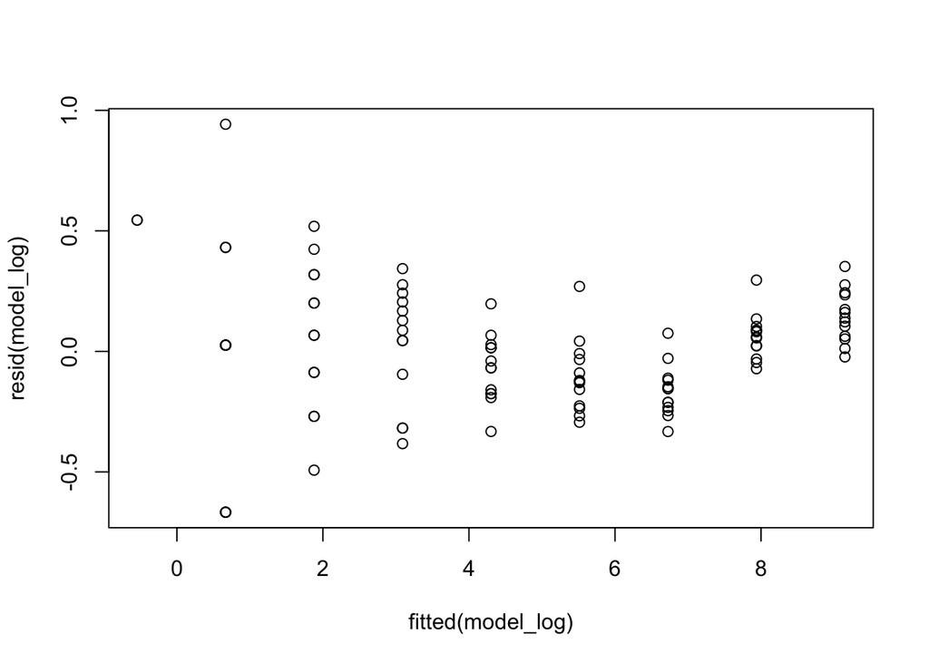

```r
model_log <- lm(log(N) ~ mag.binned, data = quakes.count)
plot(resid(model_log) ~ fitted(model_log))
```

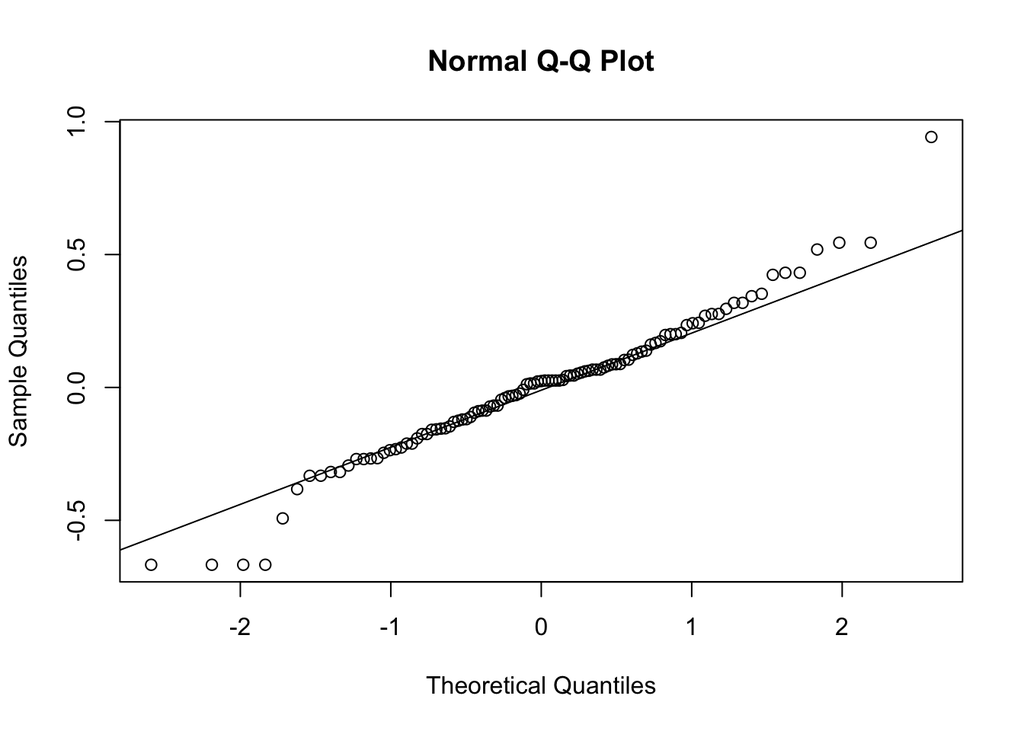

```r
qqnorm(resid(model_log))
qqline(resid(model_log))
```

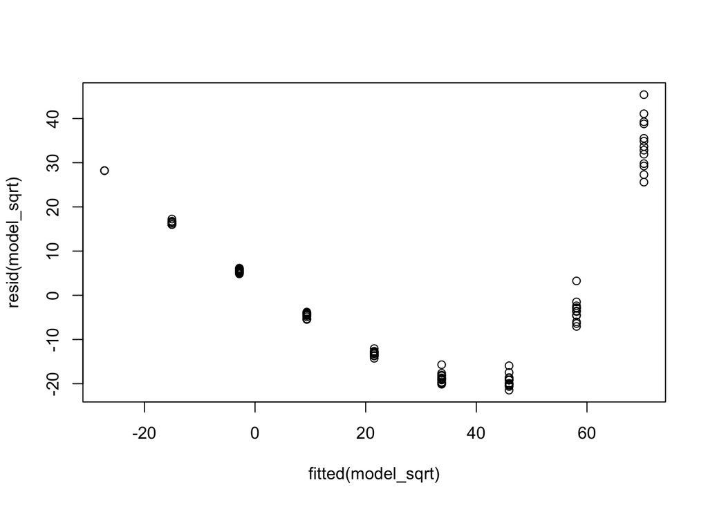

```r
model_sqrt <- lm(sqrt(N) ~ mag.binned, data = quakes.count)
plot(resid(model_sqrt) ~ fitted(model_sqrt))
```

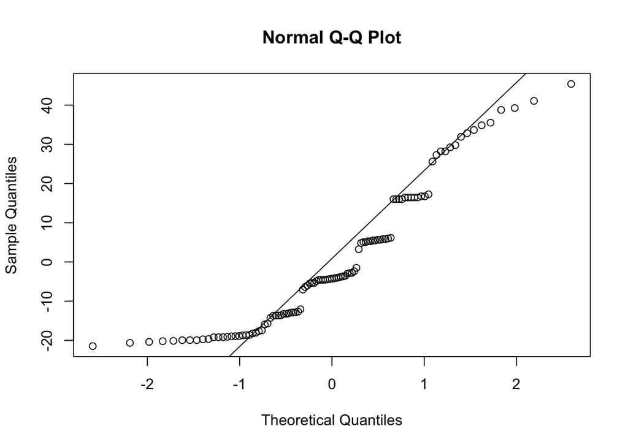

```r
qqnorm(resid(model_sqrt))
qqline(resid(model_sqrt))
```

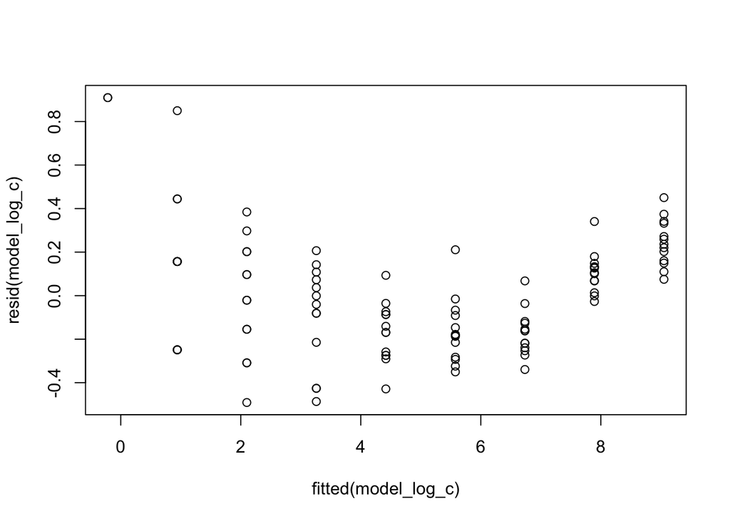

```r
model_log_c <- lm(log(N + 1) ~ mag.binned, data = quakes.count)
plot(resid(model_log_c) ~ fitted(model_log_c))
```

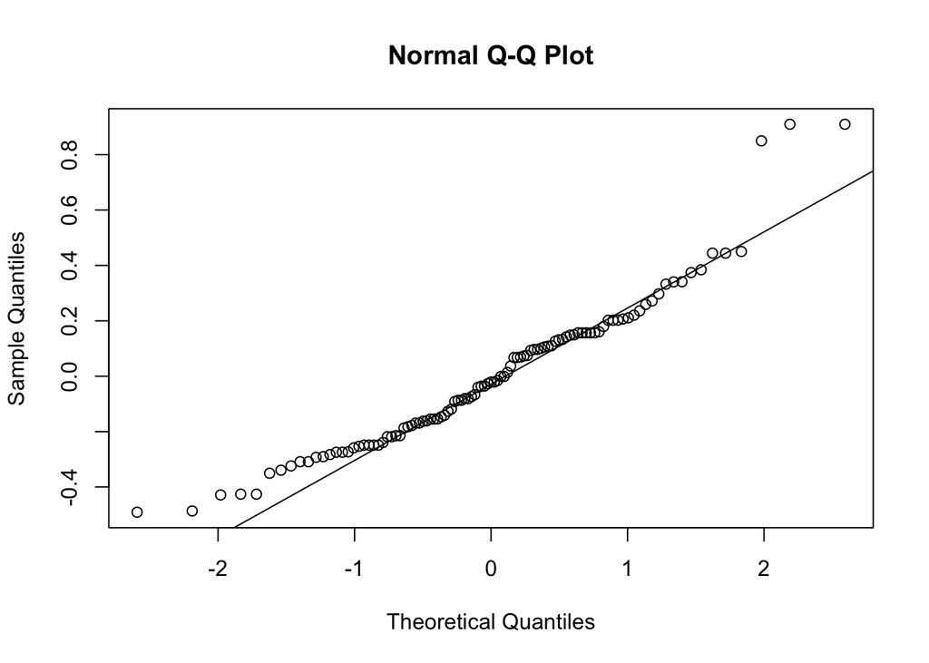

```r
qqnorm(resid(model_log_c))
qqline(resid(model_log_c))
```

### Urban Populationa and GDP

The following simulated data represents the Per Capita GDP (predictor variable) and percentage urban population for 130 countries. The data can be found in the `urbanPop_sample.csv` file.

Open the data and look at the scatter plot. What association do you tend to see in the data? Does it seem to be a linear relationship?

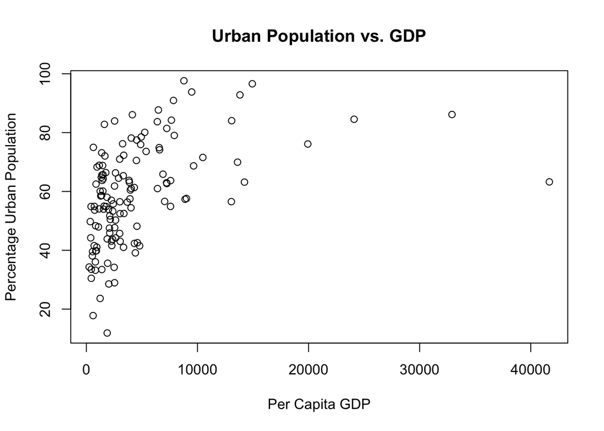

```r
urbanPop = read.csv("urbanPop_sample.csv")

#Code goes here

plot(urbanPop$GDP, urbanPop$percUrban, xlab = "Per Capita GDP", ylab = "Percentage Urban Population", main = "Urban Population vs. GDP")
```

- What I observe is a pattern where data points cluster more closely towards the lower end of the GDP axis and spread out as GDP increases, suggesting a relationship that could resemble a logarithmic curve. This pattern indicates that as GDP increases, the rate of increase in the percentage of urban population tends to decrease, fitting more closely to a log function rather than a straight line.

Try to fit a linear model to the data. Look at how poorly the straight line fits the data. Also you should check out the residual plot (`plot(lm_object, which=1))`) to see how poorly a linear model fits the data.

```r
#Code goes here

lm_basic <- lm(percUrban ~ GDP, data = urbanPop)
summary(lm_basic)
```

```
##
## Call:
## lm(formula = percUrban ~ GDP, data = urbanPop)
##
## Residuals:
##     Min      1Q  Median      3Q     Max
## -43.898 -11.001  -0.263  11.110  33.267
##
## Coefficients:
##              Estimate Std. Error t value Pr(>|t|)
## (Intercept) 5.293e+01  1.731e+00  30.581  < 2e-16 ***
## GDP         1.301e-03  2.371e-04   5.488 2.09e-07 ***
## ---
## Signif. codes:  0 '***' 0.001 '**' 0.01 '*' 0.05 '.' 0.1 ' ' 1
##
## Residual standard error: 15.45 on 128 degrees of freedom
## Multiple R-squared:  0.1905, Adjusted R-squared:  0.1842
## F-statistic: 30.12 on 1 and 128 DF,  p-value: 2.094e-07
```

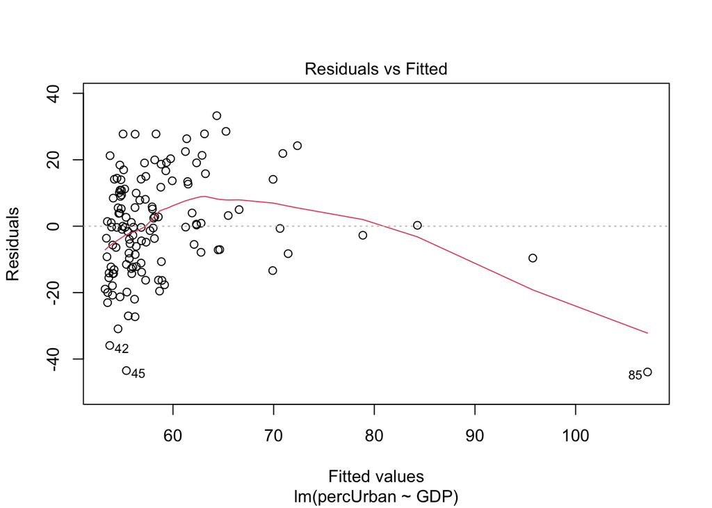

```r
plot(lm_basic, which = 1)
```

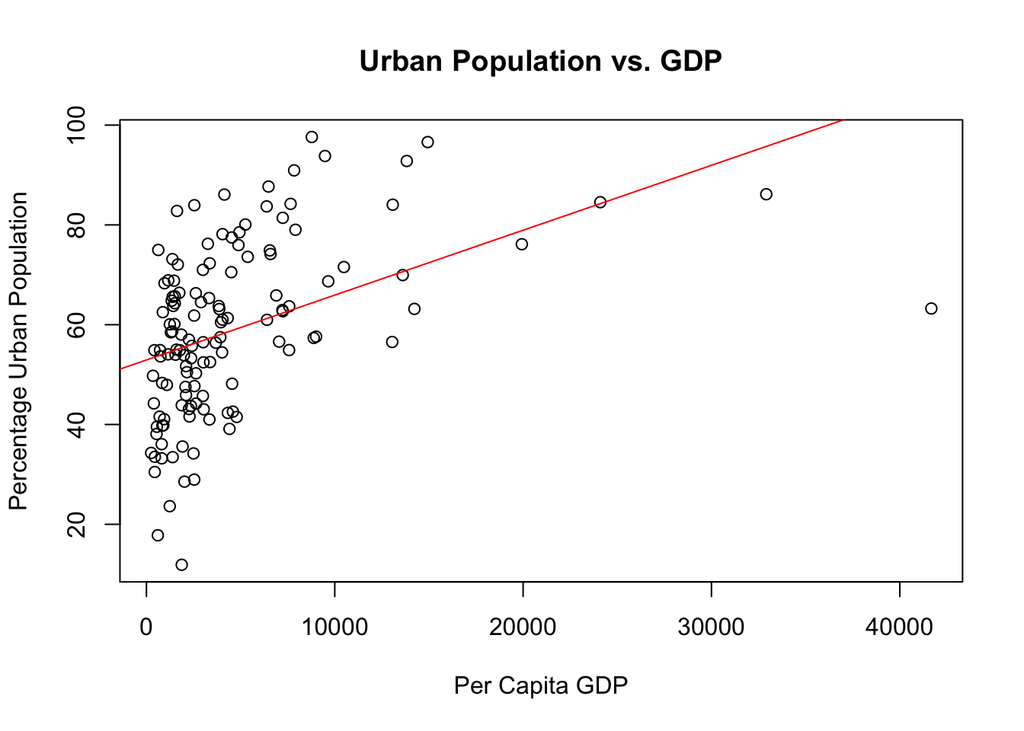

```r
plot(urbanPop$GDP, urbanPop$percUrban, main = "Urban Population vs. GDP", xlab = "Per Capita GDP", ylab = "Percentage Urban Population")
abline(lm_basic, col = "red")
```

- The red line, intended to represent the best linear approximation of the relationship between GDP and urban population percentage, fails to capture the underlying pattern observed in the scatter plot. This discrepancy suggests that the relationship between these variables is not linear but instead follows a more complex, possibly logarithmic, trend as initially suspected.

Spoiler alert - it’s not a linear relationship. However, if you perform a log transformation on GDP you will see the shape of the relationship changes dramatically. You can do this in one of two ways. You can either create a new data column `logGDP` which is simply `log(urbanPop$GDP)` or you can use the log transform inside of your `lm` formula.

Re-fit the linear model to the log-transformed GDP and look at the scatter plot.

```r
#Code goes here
lm_log <- lm(percUrban ~ log(GDP), data = urbanPop)
summary(lm_log)
```

```
##
## Call:
## lm(formula = percUrban ~ log(GDP), data = urbanPop)
##
## Residuals:
##     Min      1Q  Median      3Q     Max
## -43.141  -9.806  -1.302  11.389  30.614
##
## Coefficients:
##             Estimate Std. Error t value Pr(>|t|)
## (Intercept)  -18.496     10.078  -1.835   0.0688 .
## log(GDP)       9.757      1.262   7.733 2.72e-12 ***
## ---
## Signif. codes:  0 '***' 0.001 '**' 0.01 '*' 0.05 '.' 0.1 ' ' 1
##
## Residual standard error: 14.18 on 128 degrees of freedom
## Multiple R-squared:  0.3184, Adjusted R-squared:  0.3131
## F-statistic:  59.8 on 1 and 128 DF,  p-value: 2.72e-12
```

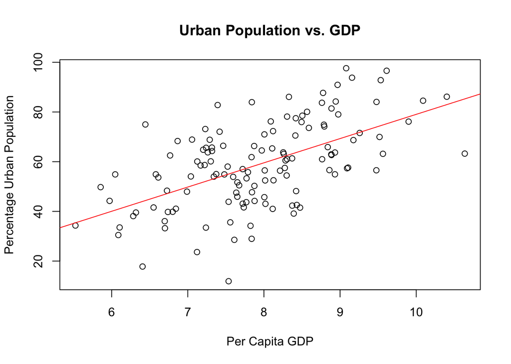

```r
plot(log(urbanPop$GDP), urbanPop$percUrban, main = "Urban Population vs. GDP", xlab = "Per Capita GDP", ylab = "Percentage Urban Population")
abline(lm_log, col = "red")
```